# Scoring Documents with LSA

4/3/2018

## Overview

In this presentation, you will learn about how you might use *L*atent *S*emantic *A*nalysis (LSA) to grade exam essay answers and gain insight into the nature of student's answers.

*Background required*: R proficiency, previous course material about semantic spaces

## Learning Objectives

- How to preprocess text documents to clean them for analysis
- How to calculate coherence of a text based on a semantic space
- How to create your own semantic space
- How to examine semantic neighborhoods to explore text documents

## LSA - Semantic Spaces

- First, you create a term by document matrix where each term is a row and documents are columns.
- This matrix is processed through singular value decomposition to reduce rows, but capture the relationship between columns (documents).
- These spaces can be used to measure similarity between terms or larger discourse.

## Example Essay Answers

```r
exam_answers = read.csv("exam_answers.csv",
                        header = F, stringsAsFactors = F)
```

> exam_answers$V1[1]

[1] "Attention - is what we choose to focus on in any given time, meaning some other information isn't being perceive/processed."

> exam_answers$V1[5]

[1] "Attention is a process that enhances information and inhibits other information. The enhancing is our brains further processing information, while inhibiting other information from interrupting the original processing. There are different roles of attention known as failures of selection and the successes of selection. The failures of selection …"

## Formatting the Answers

```r
library(ngram)

# preprocess(x, #a single string
#            case = "lower", #lower case
#            remove.punct = FALSE, #take out punctuation
#            remove.numbers = FALSE, #take out numbers
#            fix.spacing = TRUE) #fix trailing spaces

exam_answers$processed = apply(exam_answers, 1, preprocess)
```

## Load Semantic Space

- Semantic spaces are matrices in *R* that include the words as rows and the "contexts/themes" as columns.
- Several semantic spaces are provided in the package `LSAfun`, can be downloaded from the authors, or built using the `lsa` package.

```r
library(LSAfun, quietly = T)
wonderland[1:5, 1:4]
```

```
##                 [,1]          [,2]         [,3]        [,4]
## chapter -0.004465378 -0.0002703462  0.004192731 -0.00969751
## hole    -0.027648389 -0.0012134733  0.014443177  0.01939895
## rabbit  -0.138719455 -0.0156920205  0.166227329 -0.02695107
## air     -0.065620594 -0.0095096400 -0.023859310 -0.06280083
## am      -0.059077978 -0.0128348358 -0.042848175  0.02692378
```

## Coherence Example

```r
coherence(exam_answers$processed[5], #a single text answer
          tvectors = wonderland) #semantic space matrix
```

```
## $local
##  [1]           NA           NA           NA           NA  0.076283855
##  [6] -0.025124047 -0.060195968  0.011424392 -0.143776336  0.174090828
## [11] -0.053123459  0.003947319
##
## $global
## [1] -0.002059177
```

## Space Choice Matters

```r
#based on English Corpus
load(file = "EN_100k_lsa.rda") #rda files are data files
coherence(exam_answers$processed[5],
          tvectors = EN_100k_lsa) #use the English Space
```

```
## $local
##  [1] 0.9318805 0.7665503 0.7541498 0.7746313 0.7731998 0.6335128 0.6989752
##  [8] 0.8141198 0.9357841 0.8148168 0.8322362 0.8295982
##
## $global
## [1] 0.7966212
```

## How to Make a Semantic Space

```r
#Import the pdf of the book
#In general the text documents you want to analyze
library(pdftools)
book = pdf_text("PSYCHOLOGY_OF_LANGUAGE.pdf")
```

## How to Make a Semantic Space

```r
library(tm)
#Create a corpus from a vector of documents
book_corpus = Corpus(VectorSource(book))

#Lower case all words
book_corpus = tm_map(book_corpus, tolower)

#Remove punctuation for creating spaces
book_corpus = tm_map(book_corpus, removePunctuation)

#Remove stop words
book_corpus = tm_map(book_corpus,
                     function(x) removeWords(x, stopwords("english")))
```

## How to Make a Semantic Space

```r
#Create the term by document matrix
book_mat = as.matrix(TermDocumentMatrix(book_corpus))

library(lsa)

#Weight the semantic space
book_weight = lw_logtf(book_mat) * gw_idf(book_mat)

#Run the SVD
book_lsa = lsa(book_weight)

#Convert to textmatrix for coherence
book_lsa = as.textmatrix(book_lsa)
```

## Space Choice Matters

```r
#based on Book Corpus
coherence(exam_answers$processed[5],
          tvectors = book_lsa)
```

```
## $local
##  [1] 0.8382780 0.5912498 0.7265681 0.7052255 0.6247112 0.4329691 0.5219851
##  [8] 0.7849194 0.9018771 0.6324761 0.7202464 0.6815167
##
## $global
## [1] 0.6801685
```

## Examine Neighbors

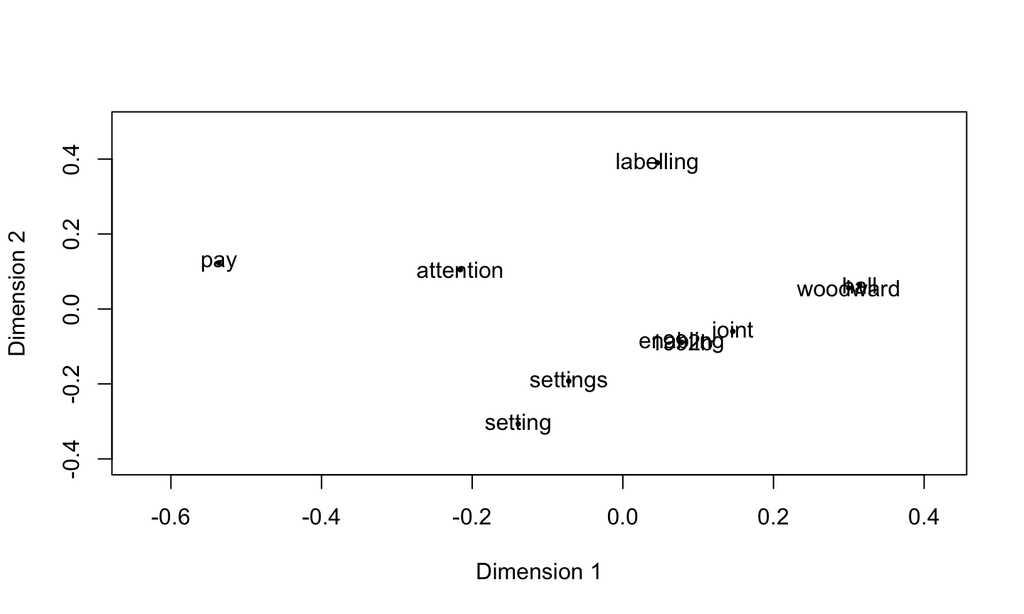

```
##                     x           y
## attention -0.21577067  0.10472351
## pay       -0.53624750  0.12263114
## 1992b      0.07825270 -0.08888274
## enabling   0.07825270 -0.08888274
## settings  -0.07175133 -0.19237428
## joint      0.14599147 -0.05983595
## setting   -0.13889655 -0.30670474
## hall       0.31443183  0.06327499
## woodward   0.29986067  0.05606942
## labelling  0.04587667  0.38998139
```

```r
plot_neighbors("attention", #single word
               n = 10, #number of neighbors
               tvectors = book_lsa, #matrix space
               method = "MDS", #PCA or MDS
               dims = 2) #number of dimensions
```

## Examine Neighbors

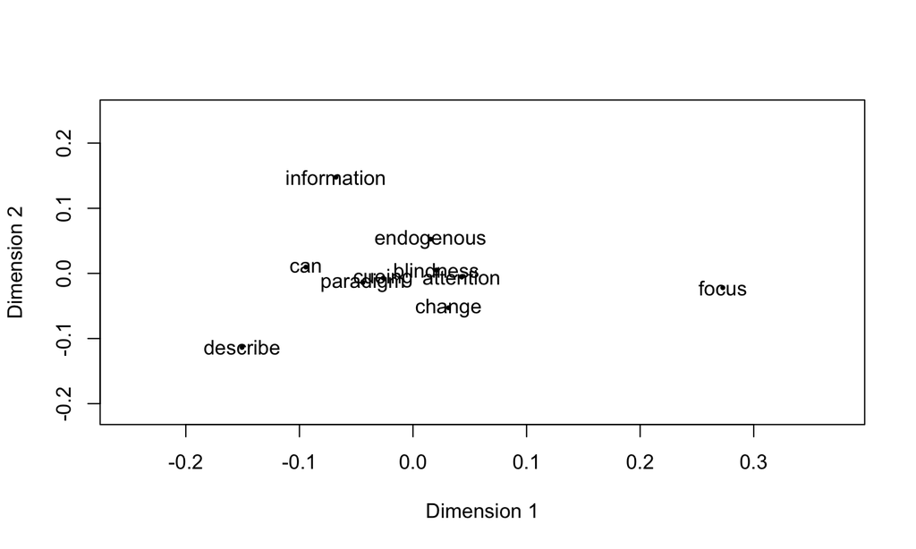

```
##                       x            y
## attention    0.04291006 -0.005573181
## blindness    0.02062525  0.005152118
## change       0.03123780 -0.052762448
## cueing      -0.02613239 -0.007109915
## endogenous   0.01538089  0.052567137
## paradigm    -0.04413785 -0.014064196
## information -0.06785719  0.147693849
## can         -0.09428705  0.009704380
## focus        0.27278638 -0.021991848
## describe    -0.15052591 -0.113615895
```

```r
plot_neighbors("attention", n = 10,
               tvectors = exam_lsa,
               method = "MDS", dims = 2)
```

## Summary

- We could use local or global coherence measures to help score exam documents.
- The definition of semantic space will heavily influence these scores.
- Neighborhoods can be examined to determine the most related themes in a semantic space.